# Fake data simulation

#### Data visualization

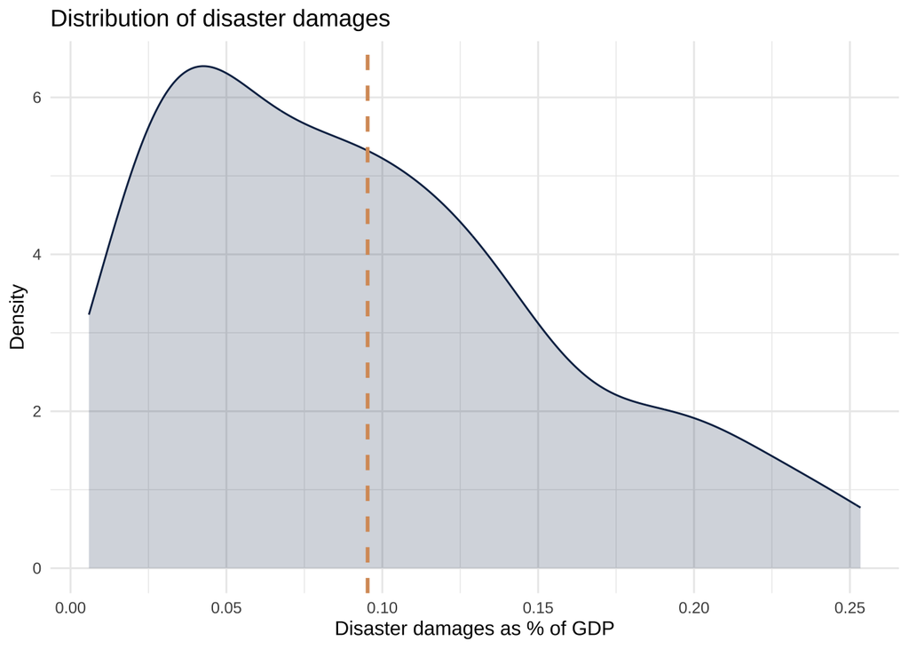

```r
#distibution of the data
data_sim |>
  ggplot(aes(x = disaster_damages)) +
  geom_density() +
  geom_vline(xintercept = mean(data_sim$disaster_damages), size = 1) +
  labs(
    title = "Distribution of disaster damages",
    x = "Disaster damages as % of GDP",
    y = "Density"
  )+
  theme_minimal()
```

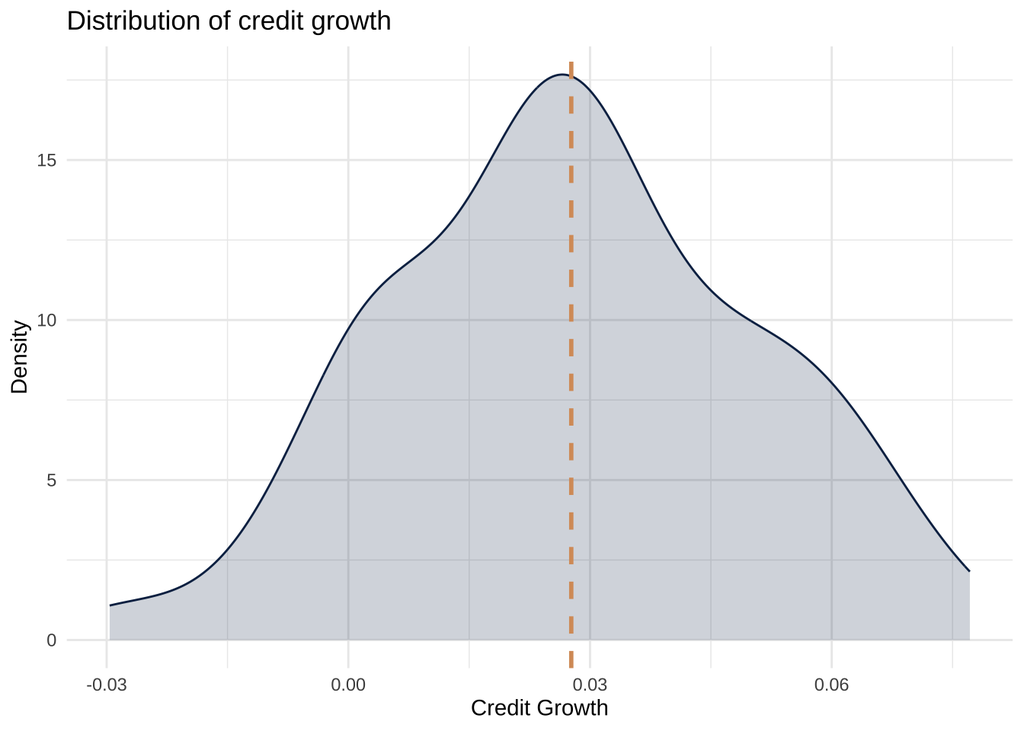

```r
data_sim |>
  ggplot(aes(x = credit_growth)) +
  geom_density() +
  geom_vline(xintercept = mean(data_sim$credit_growth), size = 1) +
  labs(
    title = "Distribution of credit growth",
    x = "Credit Growth",
    y = "Density"
  )+
  theme_minimal()
```

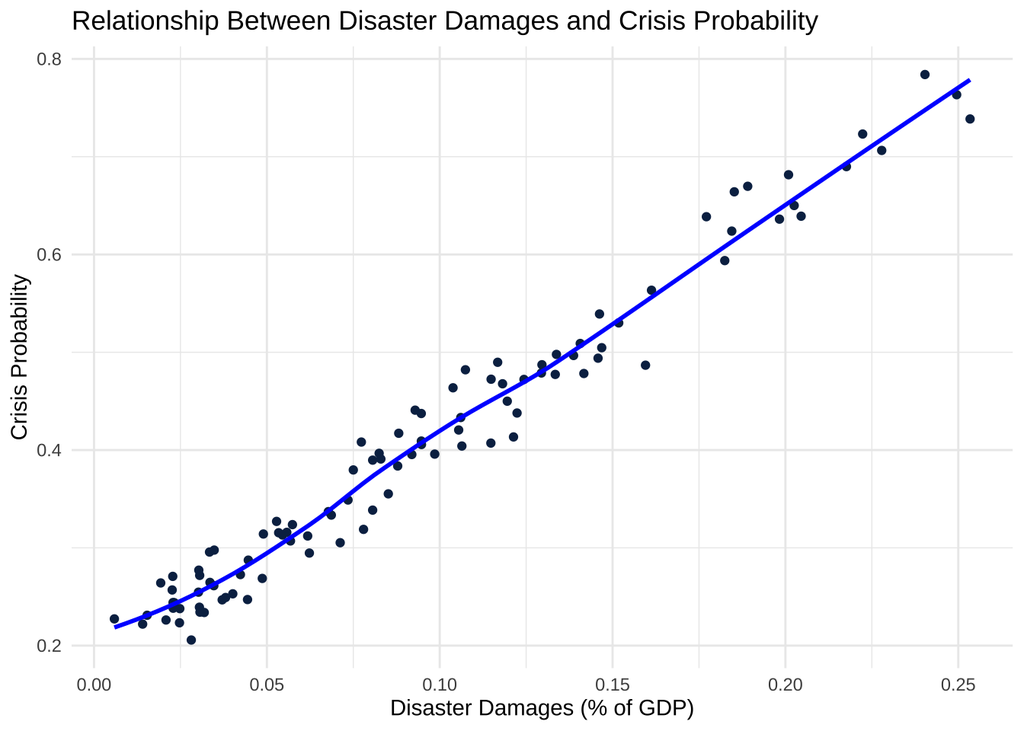

```r
# the relationship between disaster damages and crisis probability
data_sim |>
  ggplot(aes(x = disaster_damages, y = crisis_probability)) +
  geom_point() +
  geom_smooth(method = "loess", color = "blue", se = FALSE) +
  labs(
    title = "Relationship Between Disaster Damages and Crisis Probability",
    x = "Disaster Damages (% of GDP)",
    y = "Crisis Probability"
  ) +
  theme_minimal()
```

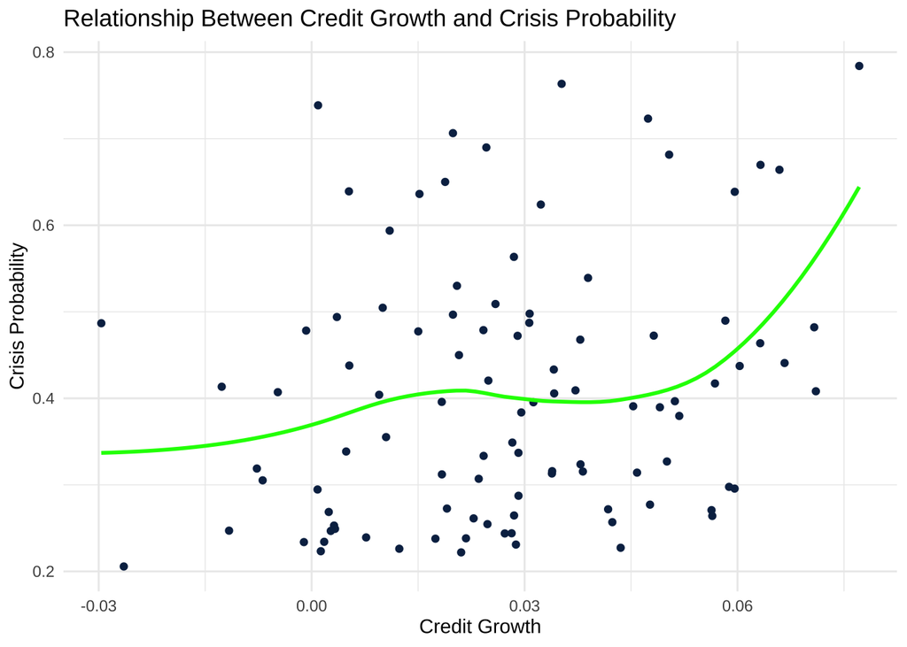

```r
# the relationship between credit growth and crisis probability
data_sim |>
  ggplot(aes(x = credit_growth, y = crisis_probability)) +
  geom_point() +
  geom_smooth(method = "loess", color = "green", se = FALSE) +
  labs(
    title = "Relationship Between Credit Growth and Crisis Probability",
    x = "Credit Growth",
    y = "Crisis Probability"
  ) +
  theme_minimal()
```

### Estimating the effects using a logistic model, as in the paper

```r
reg <- glm(crisis ~ disaster_damages + credit_growth, data = data_sim, family = binomial)
reg
```

```
Call:  glm(formula = crisis ~ disaster_damages + credit_growth, family = binomial,
    data = data_sim)

Coefficients:
     (Intercept)  disaster_damages     credit_growth
         -1.5388           10.3042           -0.5298

Degrees of Freedom: 99 Total (i.e. Null);  97 Residual
Null Deviance:      131.8
Residual Deviance: 122.6    AIC: 128.6
```

### Regression results

```r
reg_results <- broom::tidy(reg)
reg_results
```

```
# A tibble: 3 × 5
  term             estimate std.error statistic p.value
  <chr>               <dbl>     <dbl>     <dbl>   <dbl>
1 (Intercept)        -1.54      0.488   -3.15   0.00163
2 disaster_damages   10.3       3.57     2.89   0.00386
3 credit_growth      -0.530     9.68    -0.0547 0.956
```

### Coefficients for disaster damages and credit growth

```r
reg_results |>
  filter(term %in% c("disaster_damages", "credit_growth")) |>
  knitr::kable(digits = 3)
```

| term | estimate | std.error | statistic | p.value |
| --- | --- | --- | --- | --- |
| disaster_damages | 10.304 | 3.566 | 2.890 | 0.004 |
| credit_growth | -0.530 | 9.684 | -0.055 | 0.956 |

### For loop

```r
n_iter <- 100
n <- 100
res <- NULL

# Simulation parameters from our model
set.seed(42)
beta_damages <- 10 #
beta_credit <- 5
alpha <- -3
mean_damages <- 0.1
skewness <- 2
mean_credit_growth <- 0.03
sd_credit_growth <- 0.02
sigma_u <- 1.5

for (i in 1:n_iter) {
  disaster_damages <- rgamma(n, shape = 2, scale = mean_damages / skewness)
  credit_growth <- rnorm(n, mean_credit_growth, sd_credit_growth)

  log_odds_crisis <- alpha + beta_damages * disaster_damages + beta_credit * credit_growth
  crisis_probability <- 1 / (1 + exp(-log_odds_crisis))
  crisis <- rbernoulli(n, crisis_probability)
  u <- rnorm(n, 0, sigma_u)

  data_sim <- tibble(
    disaster_damages,
    credit_growth,
    crisis,
    u
  )

  reg <- glm(crisis ~ disaster_damages + credit_growth, data = data_sim, family = binomial)

  coef_table <- broom::tidy(reg)
  conf_intervals <- confint(reg)

  coef_table <- coef_table |>
    mutate(
      conf.low = conf_intervals[, 1],
      conf.high = conf_intervals[, 2]
    )

  # Filter for terms of interest and add simulation ID
  coef_table <- coef_table |>
    filter(term %in% c("disaster_damages", "credit_growth")) |>
    mutate(sim_id = i)

  res <- bind_rows(res, coef_table)
}

res |>
  filter(sim_id <= 10) |>
  knitr::kable(digits = 3) |>
  kableExtra::scroll_box(height = "250px")
```

| term | estimate | std.error | statistic | p.value | conf.low | conf.high | sim_id |
| --- | --- | --- | --- | --- | --- | --- | --- |
| disaster_damages | 11.908 | 4.868 | 2.446 | 0.014 | 2.565 | 21.964 | 1 |
| credit_growth | 18.690 | 14.614 | 1.279 | 0.201 | -9.173 | 48.854 | 1 |
| disaster_damages | 15.727 | 4.533 | 3.470 | 0.001 | 7.662 | 25.908 | 2 |
| credit_growth | 28.624 | 26.323 | 1.087 | 0.277 | -18.172 | 87.055 | 2 |
| disaster_damages | 7.371 | 3.347 | 2.202 | 0.028 | 0.957 | 14.341 | 3 |
| credit_growth | 3.055 | 14.728 | 0.207 | 0.836 | -25.833 | 32.380 | 3 |
| disaster_damages | 13.001 | 4.543 | 2.862 | 0.004 | 4.432 | 22.556 | 4 |
| credit_growth | -11.843 | 15.126 | -0.783 | 0.434 | -41.937 | 18.135 | 4 |
| disaster_damages | 12.717 | 3.620 | 3.513 | 0.000 | 6.204 | 20.570 | 5 |
| credit_growth | -11.833 | 15.392 | -0.769 | 0.442 | -43.088 | 17.927 | 5 |
| disaster_damages | 7.966 | 2.963 | 2.689 | 0.007 | 2.285 | 14.119 | 6 |
| credit_growth | -8.836 | 13.915 | -0.635 | 0.525 | -36.418 | 18.737 | 6 |
| disaster_damages | 7.886 | 3.152 | 2.501 | 0.012 | 1.823 | 14.396 | 7 |
| credit_growth | 17.046 | 15.716 | 1.085 | 0.278 | -12.618 | 49.602 | 7 |
| disaster_damages | 13.294 | 5.273 | 2.521 | 0.012 | 3.318 | 24.313 | 8 |
| credit_growth | 43.396 | 17.022 | 2.549 | 0.011 | 11.998 | 79.486 | 8 |
| disaster_damages | 9.396 | 3.267 | 2.876 | 0.004 | 3.190 | 16.158 | 9 |
| credit_growth | 2.282 | 12.172 | 0.188 | 0.851 | -21.386 | 26.820 | 9 |
| disaster_damages | 8.784 | 3.281 | 2.677 | 0.007 | 2.629 | 15.797 | 10 |
| credit_growth | 1.565 | 15.610 | 0.100 | 0.920 | -29.235 | 32.680 | 10 |

### Statistical power of the analysis

```r
power_damages <- mean(res |> filter(term == "disaster_damages") |> pull(p.value) < 0.05)
cat("The statistical power for detecting the effect of disaster damages is:", round(power_damages * 100, 2), "%\n")
```

```
The statistical power for detecting the effect of disaster damages is: 80 %
```

### “Base” model simulation

```r
generate_data <- function(n,
                          alpha,
                          beta_damages,
                          beta_credit,
                          mean_damages,
                          skewness,
                          mean_credit_growth,
                          sd_credit_growth,
                          sd_error) {

  disaster_damages <- rgamma(n, shape = 2, scale = mean_damages / skewness)

  credit_growth <- rnorm(n, mean_credit_growth, sd_credit_growth)

  error_term <- rnorm(n, mean = 0, sd = sd_error)

  log_odds_crisis <- alpha + beta_damages * disaster_damages + beta_credit * credit_growth + error_term

  crisis_probability <- 1 / (1 + exp(-log_odds_crisis))

  crisis <- rbernoulli(n, crisis_probability)

  tibble(disaster_damages, credit_growth, crisis)
}

run_estim <- function(data) {
  glm(crisis ~ disaster_damages + credit_growth, data = data, family = binomial) |>
    broom::tidy() |>
    filter(term %in% c("disaster_damages", "credit_growth"))
}

compute_sim <- function(n, alpha, beta_damages, beta_credit, mean_damages, skewness, mean_credit_growth, sd_credit_growth, sd_error) {
  data <- generate_data(
    n = n,
    alpha = alpha,
    beta_damages = beta_damages,
    beta_credit = beta_credit,
    mean_damages = mean_damages,
    skewness = skewness,
    mean_credit_growth = mean_credit_growth,
    sd_credit_growth = sd_credit_growth,
    sd_error = sd_error
  )

  results <- run_estim(data)

  results |>
    mutate(
      n = n,
      alpha = alpha,
      beta_damages = beta_damages,
      beta_credit = beta_credit,
      mean_damages = mean_damages,
      skewness = skewness,
      mean_credit_growth = mean_credit_growth,
      sd_credit_growth = sd_credit_growth,
      sd_error = sd_error
    )
}

baseline_param <- tibble(
  n = 100,
  alpha = -3,
  beta_damages = 10,
  beta_credit = 5,
  mean_damages = 0.1,
  skewness = 2,
  mean_credit_growth = 0.03,
  sd_credit_growth = 0.02,
  sd_error = 1.5
)
n_iter <- 100

param <- baseline_param |>
  uncount(n_iter)

result_sim <- param |>
  purrr::pmap(compute_sim) |>
  list_rbind()

result_sim |>
  knitr::kable() |>
  kableExtra::scroll_box(height = "200px", width = "100%")
```

| term | estimate | std.error | statistic | p.value | n | alpha | beta_damages | beta_credit | mean_damages | skewness | mean_credit_growth | sd_credit_growth | sd_error |
| --- | --- | --- | --- | --- | --- | --- | --- | --- | --- | --- | --- | --- | --- |
| disaster_damages | 8.0444860 | 3.304987 | 2.4340449 | 0.0149311 | 100 | -3 | 10 | 5 | 0.1 | 2 | 0.03 | 0.02 | 1.5 |
| credit_growth | 16.6190245 | 13.128261 | 1.2658969 | 0.2055500 | 100 | -3 | 10 | 5 | 0.1 | 2 | 0.03 | 0.02 | 1.5 |
| disaster_damages | 8.0204832 | 2.861044 | 2.8033414 | 0.0050576 | 100 | -3 | 10 | 5 | 0.1 | 2 | 0.03 | 0.02 | 1.5 |
| credit_growth | 9.0280162 | 12.146909 | 0.7432357 | 0.4573390 | 100 | -3 | 10 | 5 | 0.1 | 2 | 0.03 | 0.02 | 1.5 |
| disaster_damages | 3.5178237 | 3.526188 | 0.9976280 | 0.3184598 | 100 | -3 | 10 | 5 | 0.1 | 2 | 0.03 | 0.02 | 1.5 |
| credit_growth | -0.3755732 | 10.784718 | -0.0348246 | 0.9722196 | 100 | -3 | 10 | 5 | 0.1 | 2 | 0.03 | 0.02 | 1.5 |
| disaster_damages | 6.0876542 | 3.275336 | 1.8586349 | 0.0630789 | 100 | -3 | 10 | 5 | 0.1 | 2 | 0.03 | 0.02 | 1.5 |
| credit_growth | -3.8357414 | 11.661509 | -0.3289232 | 0.7422137 | 100 | -3 | 10 | 5 | 0.1 | 2 | 0.03 | 0.02 | 1.5 |
| disaster_damages | 5.4023166 | 2.627173 | 2.0563233 | 0.0397514 | 100 | -3 | 10 | 5 | 0.1 | 2 | 0.03 | 0.02 | 1.5 |
| credit_growth | 10.5360952 | 12.617026 | 0.8350697 | 0.4036785 | 100 | -3 | 10 | 5 | 0.1 | 2 | 0.03 | 0.02 | 1.5 |
| disaster_damages | 4.9560234 | 3.034013 | 1.6334881 | 0.1023664 | 100 | -3 | 10 | 5 | 0.1 | 2 | 0.03 | 0.02 | 1.5 |
| credit_growth | -2.3938077 | 12.445208 | -0.1923477 | 0.8474698 | 100 | -3 | 10 | 5 | 0.1 | 2 | 0.03 | 0.02 | 1.5 |
| disaster_damages | 8.7566956 | 4.288709 | 2.0418023 | 0.0411711 | 100 | -3 | 10 | 5 | 0.1 | 2 | 0.03 | 0.02 | 1.5 |
| credit_growth | 6.9458707 | 13.651816 | 0.5087873 | 0.6109013 | 100 | -3 | 10 | 5 | 0.1 | 2 | 0.03 | 0.02 | 1.5 |
| disaster_damages | 8.5463074 | 3.510850 | 2.4342561 | 0.0149224 | 100 | -3 | 10 | 5 | 0.1 | 2 | 0.03 | 0.02 | 1.5 |
| credit_growth | 41.4686117 | 15.203667 | 2.7275402 | 0.0063808 | 100 | -3 | 10 | 5 | 0.1 | 2 | 0.03 | 0.02 | 1.5 |
| disaster_damages | 5.9348576 | 3.890494 | 1.5254765 | 0.1271403 | 100 | -3 | 10 | 5 | 0.1 | 2 | 0.03 | 0.02 | 1.5 |
| credit_growth | -26.2742877 | 13.577571 | -1.9351244 | 0.0529750 | 100 | -3 | 10 | 5 | 0.1 | 2 | 0.03 | 0.02 | 1.5 |
| disaster_damages | 12.6266601 | 3.458759 | 3.6506329 | 0.0002616 | 100 | -3 | 10 | 5 | 0.1 | 2 | 0.03 | 0.02 | 1.5 |
| credit_growth | -6.9951427 | 14.917661 | -0.4689169 | 0.6391291 | 100 | -3 | 10 | 5 | 0.1 | 2 | 0.03 | 0.02 | 1.5 |
| disaster_damages | 3.2395849 | 3.327592 | 0.9735523 | 0.3302789 | 100 | -3 | 10 | 5 | 0.1 | 2 | 0.03 | 0.02 | 1.5 |
| credit_growth | -8.5218832 | 13.122496 | -0.6494102 | 0.5160732 | 100 | -3 | 10 | 5 | 0.1 | 2 | 0.03 | 0.02 | 1.5 |
| disaster_damages | 6.8975136 | 3.030433 | 2.2760816 | 0.0228411 | 100 | -3 | 10 | 5 | 0.1 | 2 | 0.03 | 0.02 | 1.5 |
| credit_growth | -0.9476554 | 13.786804 | -0.0687364 | 0.9451994 | 100 | -3 | 10 | 5 | 0.1 | 2 | 0.03 | 0.02 | 1.5 |
| disaster_damages | 7.6001979 | 3.873598 | 1.9620511 | 0.0497565 | 100 | -3 | 10 | 5 | 0.1 | 2 | 0.03 | 0.02 | 1.5 |
| credit_growth | 7.1438212 | 12.156667 | 0.5876464 | 0.5567697 | 100 | -3 | 10 | 5 | 0.1 | 2 | 0.03 | 0.02 | 1.5 |
| disaster_damages | 4.2275226 | 4.254195 | 0.9937304 | 0.3203541 | 100 | -3 | 10 | 5 | 0.1 | 2 | 0.03 | 0.02 | 1.5 |
| credit_growth | 19.2739887 | 11.587961 | 1.6632770 | 0.0962570 | 100 | -3 | 10 | 5 | 0.1 | 2 | 0.03 | 0.02 | 1.5 |
| disaster_damages | 4.4744903 | 3.653624 | 1.2246719 | 0.2206989 | 100 | -3 | 10 | 5 | 0.1 | 2 | 0.03 | 0.02 | 1.5 |
| credit_growth | -0.6442384 | 12.959393 | -0.0497121 | 0.9603518 | 100 | -3 | 10 | 5 | 0.1 | 2 | 0.03 | 0.02 | 1.5 |

[output cut: 170 more lines]

```r
summary_table <- result_sim |>
  filter(term %in% c("disaster_damages", "credit_growth")) |>
  group_by(term) |>
  summarise(
    estimate_mean = mean(estimate),
    std_error_mean = mean(std.error),
    p_value_mean = mean(p.value),
    .groups = "drop"
  )

summary_table |>
  knitr::kable(digits = 3, caption = "Aggregated Regression Results Across Simulations") |>
  kableExtra::kable_styling(bootstrap_options = c("striped", "hover", "condensed"),
                            full_width = FALSE)
```

Aggregated Regression Results Across Simulations

| term | estimate_mean | std_error_mean | p_value_mean |
| --- | --- | --- | --- |
| credit_growth | 3.588 | 12.982 | 0.505 |
| disaster_damages | 6.759 | 3.531 | 0.135 |

### Statistical power test

```r
power_damages <- mean(result_sim |> filter(term == "disaster_damages") |> pull(p.value) < 0.05)
cat("The statistical power for detecting the effect of disaster damages is:", round(power_damages * 100, 2), "%\n")
```

```
The statistical power for detecting the effect of disaster damages is: 53 %
```

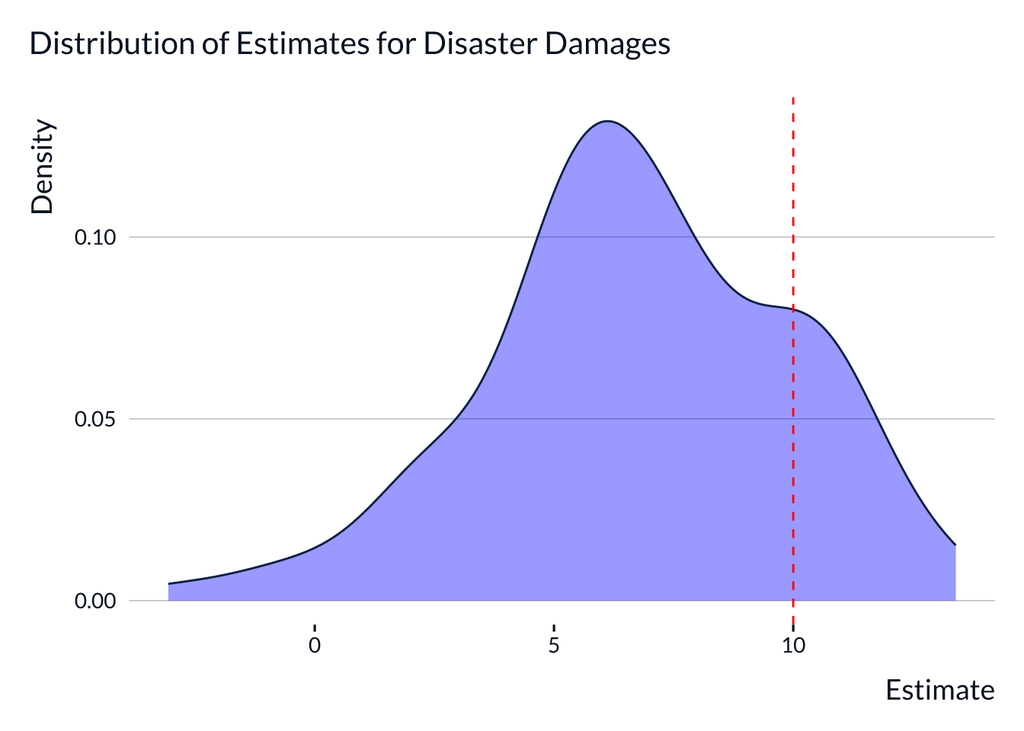

```r
result_sim |>
  filter(term == "disaster_damages") |>
  ggplot(aes(x = estimate)) +
  geom_density(fill = "blue", alpha = 0.4) +
  geom_vline(xintercept = 10, color = "red", linetype = "dashed") +
  labs(
    title = "Distribution of Estimates for Disaster Damages",
    x = "Estimate",
    y = "Density"
  )
```

```r
n_iter <- 500
vect_n <- seq(from = 100, to = 500, by = 100)

baseline_param <- baseline_param |>
  rename(n_baseline = n)

param_var_n <- baseline_param |>
  crossing(n = vect_n) |>
  uncount(n_iter)

param_var_n |>
  slice(1:10) |>
  knitr::kable() |>
  kableExtra::scroll_box(height = "200px", width = "100%")
```

| n_baseline | alpha | beta_damages | beta_credit | mean_damages | skewness | mean_credit_growth | sd_credit_growth | sd_error | n |
| --- | --- | --- | --- | --- | --- | --- | --- | --- | --- |
| 100 | -3 | 10 | 5 | 0.1 | 2 | 0.03 | 0.02 | 1.5 | 100 |
| 100 | -3 | 10 | 5 | 0.1 | 2 | 0.03 | 0.02 | 1.5 | 100 |
| 100 | -3 | 10 | 5 | 0.1 | 2 | 0.03 | 0.02 | 1.5 | 100 |
| 100 | -3 | 10 | 5 | 0.1 | 2 | 0.03 | 0.02 | 1.5 | 100 |
| 100 | -3 | 10 | 5 | 0.1 | 2 | 0.03 | 0.02 | 1.5 | 100 |
| 100 | -3 | 10 | 5 | 0.1 | 2 | 0.03 | 0.02 | 1.5 | 100 |
| 100 | -3 | 10 | 5 | 0.1 | 2 | 0.03 | 0.02 | 1.5 | 100 |
| 100 | -3 | 10 | 5 | 0.1 | 2 | 0.03 | 0.02 | 1.5 | 100 |
| 100 | -3 | 10 | 5 | 0.1 | 2 | 0.03 | 0.02 | 1.5 | 100 |
| 100 | -3 | 10 | 5 | 0.1 | 2 | 0.03 | 0.02 | 1.5 | 100 |

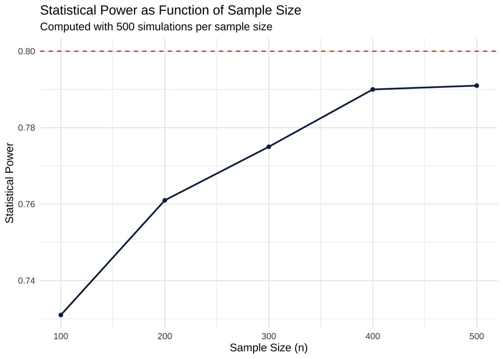

```r
param_var_n_clean <- param_var_n |>
  dplyr::select(
    n, alpha, beta_damages, beta_credit, mean_damages, skewness, mean_credit_growth, sd_credit_growth, sd_error
  )

sim_res_var_n <- param_var_n_clean |>
  purrr::pmap_dfr(.f = compute_sim, .progress = TRUE)

sim_power_var_n <- sim_res_var_n |>
  mutate(signif = (p.value < 0.5)) |>
  group_by(n) |>
  summarise(
    power = mean(signif),
    se_power = sd(signif) / sqrt(n_iter)
  )

sim_power_var_n |>
  ggplot(aes(x = n, y = power)) +
  geom_point() +
  geom_line() +
  geom_hline(yintercept = 0.8, linetype = "dashed", color = "red") +  # 80% power threshold
  labs(
    title = "Statistical Power as Function of Sample Size",
    subtitle = paste("Computed with", n_iter, "simulations per sample size"),
    x = "Sample Size (n)",
    y = "Statistical Power"
  ) +
  theme_minimal()
```

### The Credit Role Model

This simulation replicated the “credit role model” described in the paper to evaluate the interaction between **disaster damages** and **credit growth** in predicting financial crises. Credit growth was modeled as a separate variable and interacted with disaster damages to test whether their combined effects significantly amplify crisis risk.

```r
generate_data <- function(n,
                          alpha,
                          beta_damages,
                          beta_credit,
                          beta_interaction,
                          beta_control,
                          mean_damages,
                          skewness,
                          mean_credit_growth,
                          sd_credit_growth,
                          mean_control,
                          sd_control,
                          sd_error) {

  disaster_damages <- rgamma(n, shape = 2, scale = mean_damages / skewness)

  credit_growth <- rnorm(n, mean_credit_growth, sd_credit_growth)

  control_var <- rnorm(n, mean_control, sd_control)

  error_term <- rnorm(n, mean = 0, sd = sd_error)

  log_odds_crisis <- alpha +
    beta_damages * disaster_damages +
    beta_credit * credit_growth +
    beta_interaction * disaster_damages * credit_growth +
    beta_control * control_var +
    error_term

  crisis_probability <- 1 / (1 + exp(-log_odds_crisis))

  crisis <- rbernoulli(n, crisis_probability)

  tibble(
    disaster_damages,
    credit_growth,
    control_var,
    crisis
  )
}

compute_sim <- function(n, alpha, beta_damages, beta_credit, beta_interaction, beta_control,
                        mean_damages, skewness, mean_credit_growth, sd_credit_growth,
                        mean_control, sd_control, sd_error) {

  data <- generate_data(
    n = n,
    alpha = alpha,
    beta_damages = beta_damages,
    beta_credit = beta_credit,
    beta_interaction = beta_interaction,
    beta_control = beta_control,
    mean_damages = mean_damages,
    skewness = skewness,
    mean_credit_growth = mean_credit_growth,
    sd_credit_growth = sd_credit_growth,
    mean_control = mean_control,
    sd_control = sd_control,
    sd_error = sd_error
  )

  results <- glm(crisis ~ disaster_damages + credit_growth + disaster_damages:credit_growth + control_var,
                 data = data, family = binomial) |>
    broom::tidy()

  results |>
    mutate(
      n = n,
      alpha = alpha,
      beta_damages = beta_damages,
      beta_credit = beta_credit,
      beta_interaction = beta_interaction,
      beta_control = beta_control,
      mean_damages = mean_damages,
      skewness = skewness,
      mean_credit_growth = mean_credit_growth,
      sd_credit_growth = sd_credit_growth,
      mean_control = mean_control,
      sd_control = sd_control,
      sd_error = sd_error
    )
}

baseline_param <- tibble(
  n = 100,
  alpha = -3,
  beta_damages = 10,
  beta_credit = 5,
  beta_interaction = 3,
  beta_control = 2,
  mean_damages = 0.1,
  skewness = 2,
  mean_credit_growth = 0.03,
  sd_credit_growth = 0.02,
  mean_control = 0.02,
  sd_control = 0.01,
  sd_error = 1.5
)

n_iter <- 100
param_var <- baseline_param |>
  uncount(n_iter)

sim_res <- param_var |>
  purrr::pmap_dfr(compute_sim, .progress = TRUE)

summary_table <- sim_res |>
  filter(term %in% c("disaster_damages", "credit_growth", "disaster_damages:credit_growth", "control_var")) |>
  group_by(term) |>
  summarise(
    estimate_mean = mean(estimate),
    std_error_mean = mean(std.error),
    p_value_mean = mean(p.value),
    .groups = "drop"
  )

summary_table |>
  knitr::kable(digits = 3, caption = "The Credit Role Model Results") |>
  kableExtra::kable_styling(bootstrap_options = c("striped", "hover", "condensed"),
                            full_width = FALSE)
```

The Credit Role Model Results

| term | estimate_mean | std_error_mean | p_value_mean |
| --- | --- | --- | --- |
| control_var | 1.921 | 26.545 | 0.502 |
| credit_growth | 2.887 | 25.826 | 0.491 |
| disaster_damages | 7.138 | 7.000 | 0.327 |
| disaster_damages:credit_growth | 4.069 | 199.248 | 0.505 |

### Test for Omitted Variables

### Full Model

```r
generate_data <- function(n, alpha, beta_damages, beta_credit, sd_error) {
  disaster_damages <- rgamma(n, shape = 2, scale = 0.1)

  credit_growth <- 0.02 + 0.5 * disaster_damages + rnorm(n, mean = 0, sd = sd_error)

  log_odds_crisis <- alpha +
    beta_damages * disaster_damages +
    beta_credit * credit_growth

  crisis_probability <- 1 / (1 + exp(-log_odds_crisis))

  crisis <- rbernoulli(n, crisis_probability)

  tibble(
    disaster_damages,
    credit_growth,
    crisis
  )
}

n <- 100
alpha <- -3
beta_damages <- 10
beta_credit <- 5
sd_error <- 0.02

data <- generate_data(n, alpha, beta_damages, beta_credit, sd_error)

full_model <- glm(crisis ~ disaster_damages + credit_growth, data = data, family = binomial)

full_results <- full_model |>
  broom::tidy() |>
  mutate(model = "Full Model")

full_results |>
  knitr::kable(digits = 3, caption = "Full Model Regression Results")
```

Full Model Regression Results

| term | estimate | std.error | statistic | p.value | model |
| --- | --- | --- | --- | --- | --- |
| (Intercept) | -1.908 | 0.558 | -3.419 | 0.001 | Full Model |
| disaster_damages | 12.359 | 6.715 | 1.840 | 0.066 | Full Model |
| credit_growth | -5.894 | 12.572 | -0.469 | 0.639 | Full Model |

After this, we omitted **disaster damages** from the model to test for **omitted variable bias**. By excluding disaster damages, the regression attributes their effect to credit growth, potentially inflating the credit growth coefficient. This simulation highlighted the risks of misattributing effects when a key explanatory variable is omitted, underscoring the paper’s argument for including disaster damages in models analyzing crisis risk.

```r
omit_model <- glm(crisis ~ credit_growth, data = data, family = binomial)

omit_results <- omit_model |>
  broom::tidy() |>
  mutate(model = "Omitted Variable Model")

combined_results <- bind_rows(full_results, omit_results)

combined_results |>
  knitr::kable(digits = 3, caption = "Comparison of Full Model and Omitted Variable Model Results")
```

Comparison of Full Model and Omitted Variable Model Results

| term | estimate | std.error | statistic | p.value | model |
| --- | --- | --- | --- | --- | --- |
| (Intercept) | -1.908 | 0.558 | -3.419 | 0.001 | Full Model |
| disaster_damages | 12.359 | 6.715 | 1.840 | 0.066 | Full Model |
| credit_growth | -5.894 | 12.572 | -0.469 | 0.639 | Full Model |
| (Intercept) | -2.197 | 0.541 | -4.061 | 0.000 | Omitted Variable Model |
| credit_growth | 16.364 | 4.106 | 3.985 | 0.000 | Omitted Variable Model |

The results highlight the impact of omitted variable bias: in the full model, neither disaster damages nor credit growth is statistically significant, suggesting overlapping effects or insufficient data variation. However, in the omitted variable model, the credit growth coefficient becomes highly significant, with a p-value near zero, indicating that its effect is inflated due to absorbing the explanatory power of disaster damages. This underscores the importance of including all relevant variables to avoid misattributing effects in crisis risk models.